# **プログラミング基礎第9回**

### 今回の内容

- matplotlibライブラリ
  - [ホーム](https://matplotlib.org)
  - [様々なグラフのギャラリー](https://matplotlib.org/stable/gallery/index)
- pyplotモジュール
  - [概要](https://matplotlib.org/stable/api/pyplot_summary.html)
  - [チュートリアル](https://matplotlib.org/stable/tutorials/pyplot.html)
- 今回扱うグラフの種類
  - 折れ線グラフ
  - 散布図
  - 棒グラフ
  - ヒストグラム

### 準備

- モジュールの導入
  - matpylotlib.pylotを利用するには`import`が必要
  - `pyplot`モジュールの取り込みはノート中で1回だけ行えばよい
  - ノートを再開した時には、再度,`import`を実行する
    - `import matplotlib.pyplot as plt`
- グラフの表示
  - Jupyter Notebookで結果のグラフを表示するには以下が必要
  - `Python`言語の機能ではない
    - %matplotlib inline

```python
# ノートの先頭で一度だけ実行すれば良い
%matplotlib inline
import matplotlib.pyplot as plt
import numpy as np
```

## 折れ線グラフ

matplotlib.pylot関数 https://matplotlib.org/stable/api/_as_gen/matplotlib.pyplot.plot.html

### 折れ線グラフ1(基本)

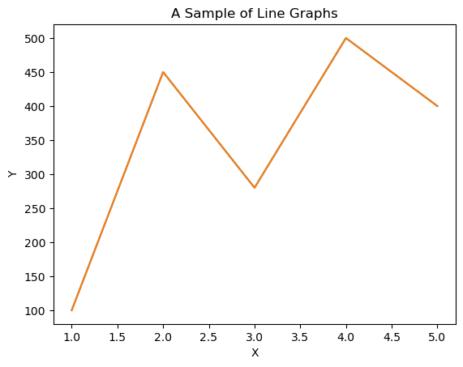

```python
X = [1,2,3,4,5]          # グラフデータX値
Y = [100,450,280,500,400]# グラフデータY値
plt.plot(X,Y)            # X横軸,Y縦軸の折れ線グラフ
plt.title('A Sample of Line Graphs')
plt.xlabel('X')
plt.ylabel('Y')
plt.show()               # これではじめてグラフの表示
```

### 折れ線グラフ2(色,マーカー,グリッド)

[figure not shown]

```python
price = [100,250,580,400,700]
month = ['Jan','Feb','Mar','Apr','May']
# マーカーと色を追加で指定
plt.plot(month, price, marker='o', color='r')
plt.grid(True)  # グリッド表示指定
plt.title('Price Movements')
plt.xlabel('Month')
plt.ylabel('Price')
plt.show()
```

### 折れ線グラフ3(複数データと凡例)

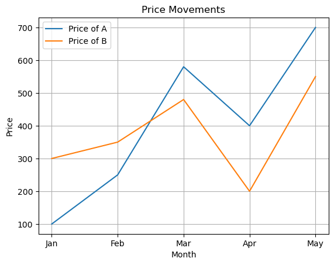

```python
M = ['Jan','Feb','Mar','Apr','May']
A = [100,250,580,400,700]
B = [300,350,480,200,550]
plt.plot(M,A,B)     # 縦軸データを複数指定する
plt.legend(['Price of A','Price of B']) # legend:凡例
plt.title('Price Movements')
plt.xlabel('Month')
plt.ylabel('Price')
plt.grid(True)
plt.show()
```

#### 折れ線グラフ4(複数データと範囲)

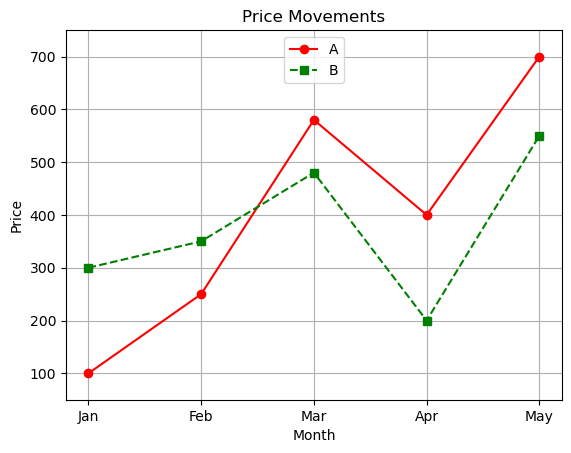

```python
plt.plot(M, A, c='r', marker='o',
         linestyle='-', label='A')   # 赤,丸,実線
plt.plot(M, B, 'gs--', label='B')   # 緑,四角,破線
ymin = min(A + B)
ymax = max(A + B)
plt.ylim(ymin - 50, ymax + 50)  # y軸の下限と上限を調整
plt.legend(loc='upper center')  # 凡例の場所指定(上中央)
plt.title('Price Movements')
plt.xlabel('Month')
plt.ylabel('Price')
plt.grid(True)
plt.show()
```

### オプション

`import`で`matplotlib.pylot`の名を`plt`とした

- `import matplotlib.pylot as plt`

その中の`plot()`関数に対する指定

```
plt.plot(Xデータ,Yデータ,'ro-',label='A')
```

- 色指定
  - `r`赤,`g`緑,`b`青,`y`黄
  - https://matplotlib.org/stable/api/colors_api.html
- マーカー指定
  - `o`円,`*`星,`x`クロス,`s`四角,`v`下三角
  - https://matplotlib.org/stable/api/markers_api.html
- 線種指定
  - `-`実線,`:`点線,`--`破線,`-.`1点単破線,`None`線なし

```
pit.legend(loc='center')
```

- 場所の指定
  - upper,lower,left,right,center,best
  - https://matplotlib.org/stable/api/legend_api.html

## 散布図

`metplotlib.pyplot.scatter`関数 https://matplotlib.org/stable/api/_as_gen/matplotlib.pyplot.scatter.html

### 準備(numpyの連続値と乱数)

- 連続値
  - `range()`関数と同様にある範囲の`numpy`配列を生成できる

```python
x = np.arange(1,11) # 1から10の連続値
print(x)
```

```
[ 1  2  3  4  5  6  7  8  9 10]
```

- numpyの乱数生成を利用する
  - コンピューターの乱数は種と呼ばれる値から複雑な関数を適用して無関係に見える値を作り出すことが多い。これを**疑似乱数**と呼ぶ。

```python
np.random.seed(5)   # 種の設定
y = np.random.rand(3)   # 0以上1未満の3個の一様分布の乱数
print(y)
z = np.random.randn(4)  # 正規分布の乱数(平均0,分散1.0)
print(z)
```

```
[0.22199317 0.87073231 0.20671916]
[-0.02330375  0.84177767  1.36758552  0.57470769]
```

### 散布図1(一様分布の乱数)

```python
np.random.seed(2)   # 乱数の種(系列決定)
x = np.arange(1,101)    # 1から100の連続値
y = 4*x*np.random.rand(100) # 100個の乱数に4とxの要素を乗じる
```

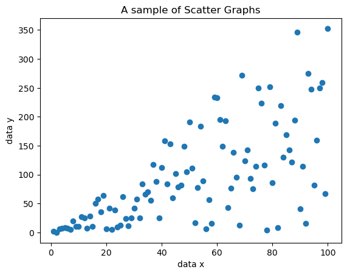

```python
plt.scatter(x,y)    # 散布図の作成
plt.title('A sample of Scatter Graphs')
plt.xlabel('data x')
plt.ylabel('data y')
plt.show()
```

### 散布図2(正規分布乱数の利用)

```python
np.random.seed(123)             # 乱数の種の設定
N = 200                         # データ数
x = np.random.rand(N)           # 一様分布の乱数
y = 2*x + np.random.randn(N)    # 正規分布の乱数
```

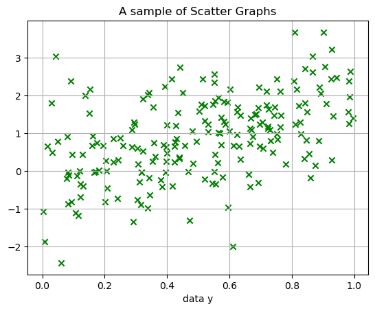

```python
plt.scatter(x,y,c='g',marker='x')   # 緑,X印
plt.title('A sample of Scatter Graphs')
plt.xlabel('data x')
plt.xlabel('data y')
plt.grid(True)
plt.show()
```

## 棒グラフ

`matplotlib.pyplot.bar`関数 https://matplotlib.org/stable/api/_as_gen/matplotlib.pyplot.bar.html

### 棒グラフ1(基本)

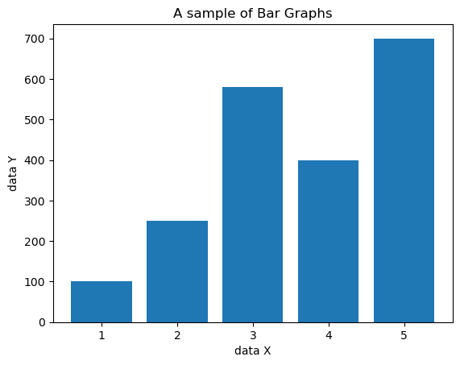

```python
X = np.arange(1,6)
Y = [100,250,580,400,700]

plt.bar(X,Y)    # 棒グラフの指定
plt.title('A sample of Bar Graphs')
plt.xlabel('data X')
plt.ylabel('data Y')
plt.show()
```

### 棒グラフ2(横軸文字列,色,Y軸グリッド)

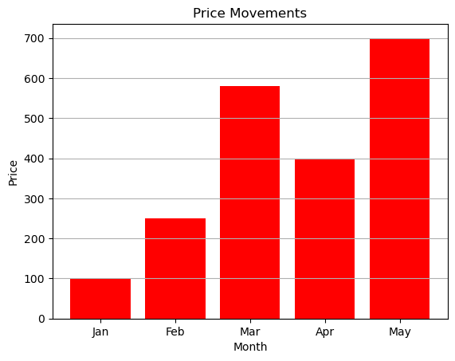

```python
month = ['Jan','Feb','Mar','Apr','May']
price = [100,250,580,400,700]

plt.bar(month,price,color='r')  # 赤
plt.title('Price Movements')
plt.xlabel('Month')
plt.ylabel('Price')
plt.grid(axis='y')  # y軸のみ
plt.show()
```

### 棒グラフ3(横向き)

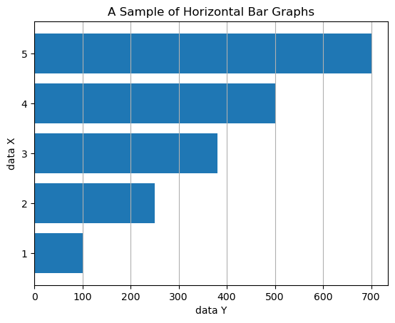

```python
X = np.arange(1,6)
Y = [100,250,380,500,700]

plt.barh(X,Y)   # 横向き(bar horizontal)
plt.title('A Sample of Horizontal Bar Graphs')
plt.xlabel('data Y')    # ラベルに注意
plt.ylabel('data X')    # xyが入れ替わる
plt.grid(axis='x')      # x軸のみ
plt.show()
```

### 棒グラフでの複数系列データ

- 複数系列データ:Y軸方向データに複数のリストを指定
- Xごとに対応するY軸方向データの棒グラフを並べたい
- 方法
  - 棒グラフの幅を決める
  - 幅の情報を使ってずらす大きさを決める
  - X軸方向のデータにずらす大きさを含ませる

```
plt.bar(Xデータ+ずらす大きさ,Yデータ,棒グラフの幅)
```

```python
# 使用するデータ
M = ['Jan','Feb','Mar','Apr','May']
A = [100,250,580,400,700]
B = [300,350,480,200,550]
C = [270,420,400,600,750]
```

### 棒グラフ4(2系列データ)

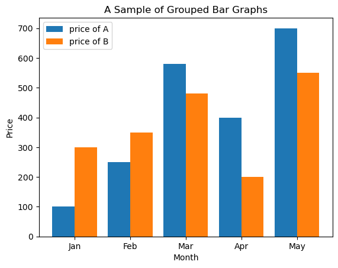

```python
x = np.arange(len(M))   # 横軸に対応させる整数
w = 0.4     # 棒の幅
plt.bar(x-w/2,A,w,label='price of A')   # 左にずらす
plt.bar(x+w/2,B,w,label='price of B')  # 右にずらす
plt.xticks(x,M) # X軸に対応するラベル
plt.title('A Sample of Grouped Bar Graphs')
plt.xlabel('Month')
plt.ylabel('Price')
plt.legend()    # 凡例
plt.show()
```

### 棒グラフ5(3系列データ)

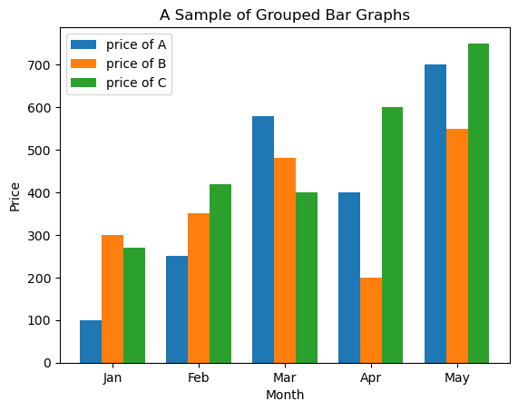

```python
x = np.arange(len(M))   # 横軸に対応させる整数
w = 0.25     # 棒の幅
plt.bar(x-w,A,w,label='price of A')  # 左にずらす
plt.bar(x,B,w,label='price of B')  # ずらさない
plt.bar(x+w,C,w,label='price of C')  # 右にずらす
plt.xticks(x,M) # X軸に対応するラベル
plt.title('A Sample of Grouped Bar Graphs')
plt.xlabel('Month')
plt.ylabel('Price')
plt.legend()    # 凡例
plt.show()
```

### 棒グラフ6(2系列積み上げ)

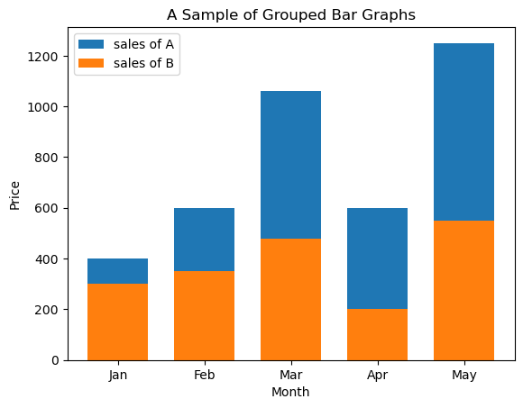

```python
w = 0.7
# Aの棒はbottom指定だけ上にずらして描画
plt.bar(M,A,w,label='sales of A',bottom=B)
plt.bar(M,B,w,label='sales of B')
plt.title('A Sample of Grouped Bar Graphs')
plt.xlabel('Month')
plt.ylabel('Price')
plt.legend()    # 凡例
plt.show()
```

### 棒グラフ7(3系列積み上げ)

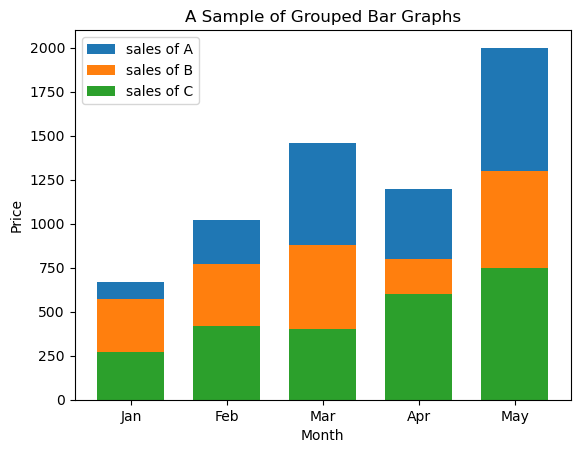

```python
m = np.arange(1,6)
BC = np.array(B)+ np.array(C)
w = 0.7
plt.bar(M,A,w,label='sales of A',bottom=BC)
plt.bar(M,B,w,label='sales of B',bottom=C)
plt.bar(M,C,w,label='sales of C')
plt.title('A Sample of Grouped Bar Graphs')
plt.xlabel('Month')
plt.ylabel('Price')
plt.legend()
plt.show()
```

## ヒストグラム

`matplotlib.pyplot.hist`関数 https://matplotlib.org/stable/api/_as_gen/matplotlib.pyplot.hist.html

### ヒストグラム1(正規部分布の乱数)

```python
np.random.seed(0)
mu = 100    # 平均
sigma = 10  # 標準偏差
x = np.random.normal(mu,sigma,10000)    # 1万個の正規分布乱数
```

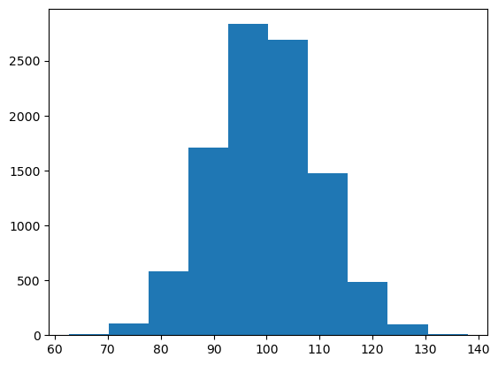

```python
# デフォルトで10個の区間のヒストグラム
plt.hist(x)
plt.show()
```

### ヒストグラム3(横向き)

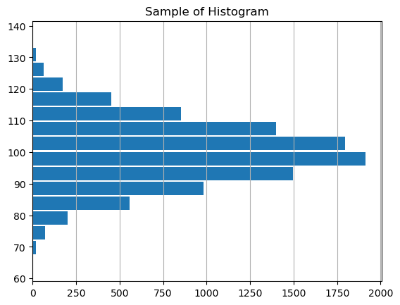

```python
# orientation:方向,horizontal:水平の,横の
plt.hist(x,rwidth=0.9,bins=16,orientation="horizontal")
plt.grid(axis='x')
plt.title('Sample of Histogram')
plt.show()
```

### ヒストグラム4(相対度数)

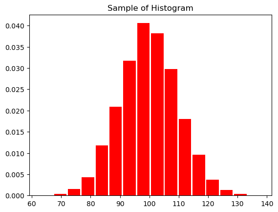

```python
# 度数の合計が1となるヒストグラム
# probability density:確率密度
plt.hist(x,rwidth=0.9,bins=16,color="r",density=True)
plt.title('Sample of Histogram')
plt.show()
```

### ヒストグラム5(累積度数)

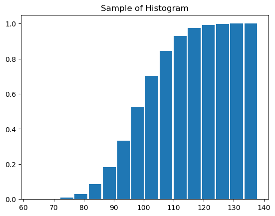

```python
# cumulative:累積の
plt.hist(x,rwidth=0.9,bins=16,density=True,cumulative=True)
plt.title('Sample of Histogram')
plt.show()
```

## グラフの日本語表示

### 準備

- インストールなので毎回のノート作成とは無関係に一度だけ行う
- 詳細はhttps://github.com/uehara1414/japanize-matplotlib

```
pip install japanize-matplotlib
```

いろいろ表示されて最後に`Successfully installed japanize-matplotlib-1.1.x`の文字列が出ればOK

### 折れ線グラフと日本語表示

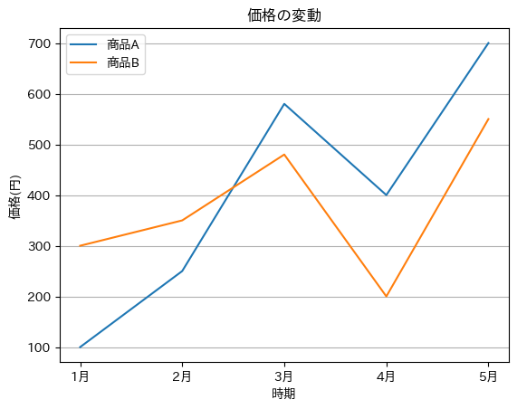

```python
import japanize_matplotlib # 他のimport同様に一度だけ必要
price_A = [100,250,580,400,700]
price_B = [300,350,480,200,550]
month = ['1月','2月','3月','4月','5月']
plt.plot(month,price_A,price_B)
plt.legend(['商品A','商品B'])
plt.title('価格の変動')
plt.xlabel('時期')
plt.ylabel('価格(円)')
plt.grid(axis='y')
plt.show()
```